# Clustering homework assignment

- You have been provided some customer data from a shopping centre. Do some exploratory analysis on the data. Comment on findings.

```r
library(tidyverse)
library(factoextra)
```

```r
library(corrplot)
library(broom)
```

```r
mall_customers <- read_csv("data/mall_customers.csv") %>%
  janitor::clean_names()
# check for missing data
any(is.na(mall_customers))
```

```
## [1] FALSE
```

```r
# count distinct data
mall_customers %>%
  summarise(across(everything(), ~ n_distinct(.x)))
```

| customer_id | gender | age | annual_income_k | spending_score_1_100 |
| --- | --- | --- | --- | --- |
| 200 | 2 | 51 | 64 | 84 |

- set row_names to `customer_id`
- set gender to factor

```r
mall_customers <- mall_customers %>%
  column_to_rownames("customer_id") %>%
  mutate(gender = as.factor(gender))
```

There are two genders which I have set as a factor character. The `customer_id` has been set as a row_name. There are no missing values. I will have a look at possible correlations in the numeric data after scaling the data.

```r
mall_customers_scale <- mall_customers %>%
  mutate_if(is.numeric, scale)

mall_customers_scale_num <- mall_customers_scale %>%
  select(is.numeric)
```

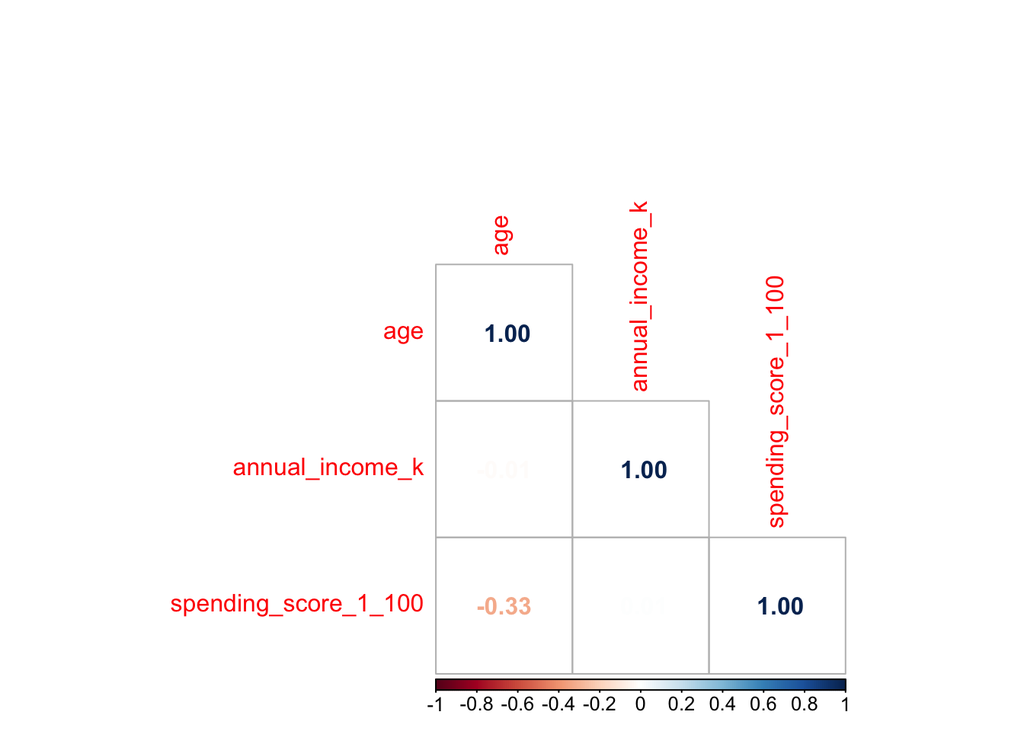

```r
corrplot(cor(mall_customers_scale_num), method = "number", type = "lower")
```

Looks like in the numeric data age and spending_score_1_100 are moderately weakly correlated.

- We are interested in creating a marketing campaign to target customers based on their spending score and annual income. Perform a k-means clustering to find if there are meaningful clusters in the data to target the customers.

```r
# make a single k-means cluster

cluster_mall <- kmeans(mall_customers_scale_num,
                       centers = 6,
                       nstart = 25)

cluster_summary <- tidy(cluster_mall,
     col.names = colnames(mall_customers_scale_num))
cluster_summary
```

| age | annual_income_k | spending_score_1_100 | size | withinss | cluster |
| --- | --- | --- | --- | --- | --- |
| -0.4408110 | 0.9891010 | 1.23640011 | 39 | 22.36267 | 1 |
| 0.4777583 | -1.3049552 | -1.19344867 | 21 | 20.52332 | 2 |
| -0.8709130 | -0.1135003 | -0.09334615 | 38 | 20.20990 | 3 |
| 1.2515802 | -0.2396117 | -0.04388764 | 45 | 23.87015 | 4 |
| 0.2211606 | 1.0805138 | -1.28682305 | 33 | 34.51630 | 5 |
| -0.9735839 | -1.3221791 | 1.03458649 | 24 | 11.71664 | 6 |

```r
glance(cluster_mall)
```

| totss | tot.withinss | betweenss | iter |
| --- | --- | --- | --- |
| 597 | 133.199 | 463.801 | 3 |

- Perform k-means clustering and chose a value of k.

```r
# set maximum numbers of clusters
k_max <- 20

k_clusters <- tibble(k = 1:k_max) %>%
  mutate(
    kclust = map(k, ~ kmeans(
      mall_customers_scale_num, .x, nstart = 25)),
    tidied = map(kclust, tidy),
    glanced = map(kclust, glance),
    augmented = map(kclust, augment, mall_customers_scale)
  )

unnested_k_clusters <- k_clusters %>%
  unnest(glanced)

unnested_k_clusters
```

| k | kclust | tidied | totss | tot.withinss | betweenss | iter | augmented |
| --- | --- | --- | --- | --- | --- | --- | --- |
| 1 |  |  | 597 | 597.00000 | 1.250555e-12 | 1 |  |
| 2 |  |  | 597 | 387.43926 | 2.095607e+02 | 1 |  |
| 3 |  |  | 597 | 293.73618 | 3.032638e+02 | 2 |  |
| 4 |  |  | 597 | 204.19902 | 3.928010e+02 | 3 |  |
| 5 |  |  | 597 | 167.40634 | 4.295937e+02 | 4 |  |
| 6 |  |  | 597 | 133.19899 | 4.638010e+02 | 3 |  |
| 7 |  |  | 597 | 116.50259 | 4.804974e+02 | 4 |  |
| 8 |  |  | 597 | 103.57735 | 4.934226e+02 | 3 |  |
| 9 |  |  | 597 | 91.49705 | 5.055029e+02 | 3 |  |
| 10 |  |  | 597 | 81.02185 | 5.159782e+02 | 4 |  |

[output cut: 10 more lines]

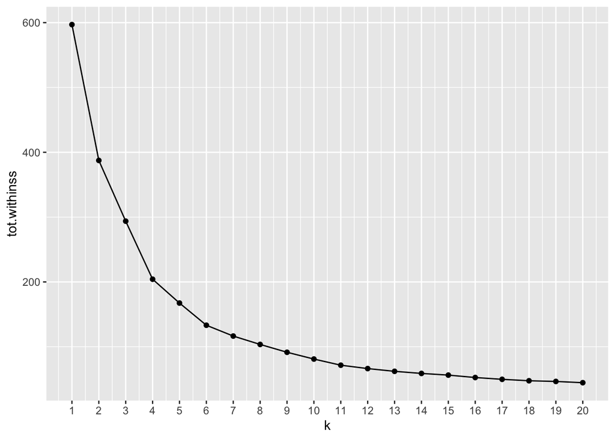

```r
# look for the "elbow"
ggplot(unnested_k_clusters) +
  aes(x = k, y = tot.withinss) +
  geom_point() +
  geom_line() +
  scale_x_continuous(breaks = seq(1,20, by = 1))
```

Looks like 2 or 4 clusters produces an elbow. Let’s check another metric to select clusters.

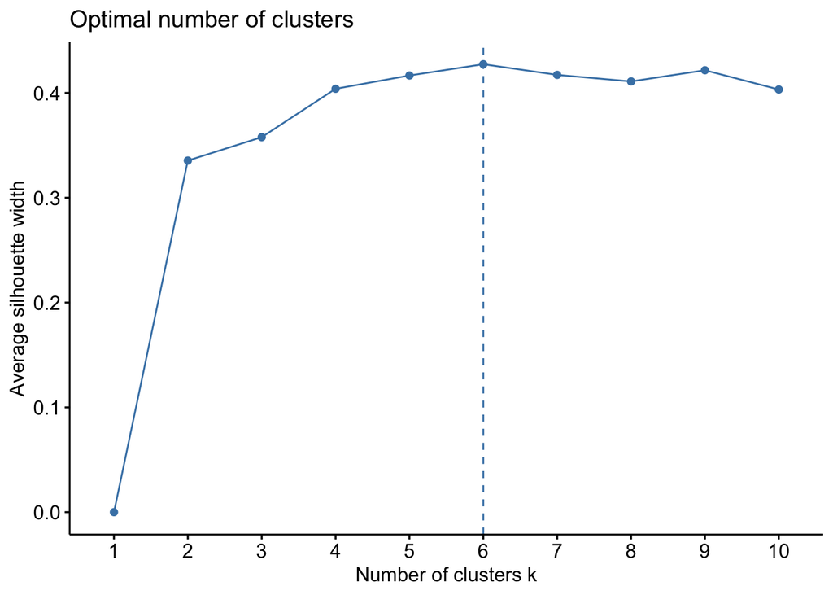

```r
library(factoextra)
fviz_nbclust(mall_customers_scale_num,
             kmeans,
             method = "silhouette",
             nstart = 25)
```

Let’s have one last look at the final metric for selecting clusters, the gap statistic.

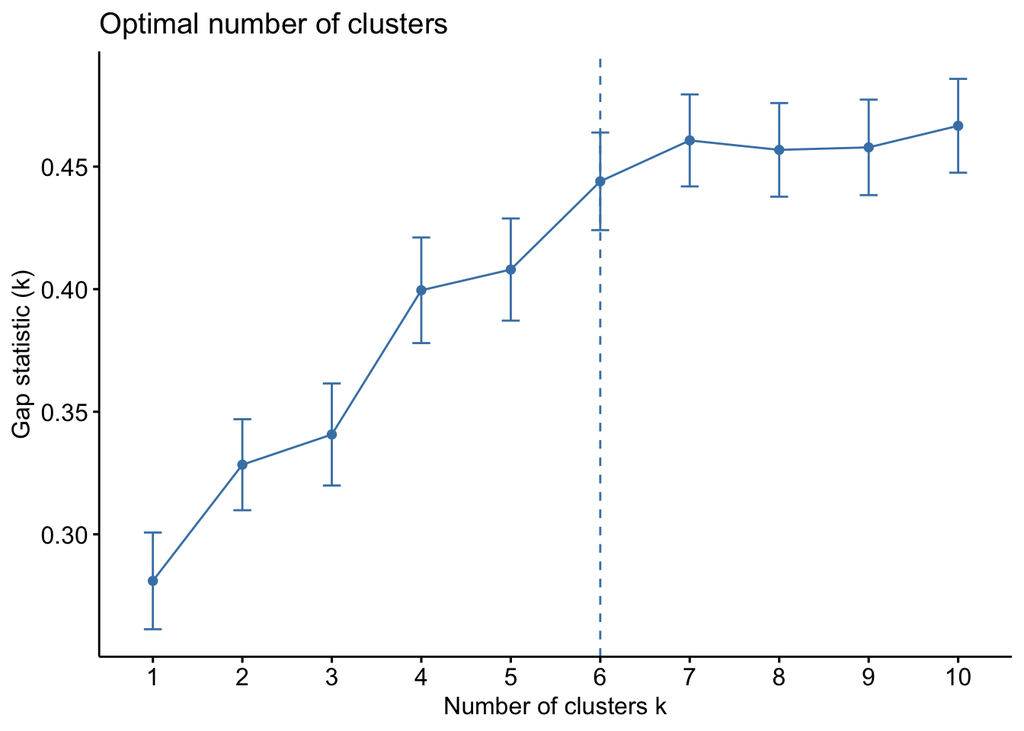

```r
fviz_nbclust(mall_customers_scale_num,
             kmeans,
             method = "gap_stat",
             nstart = 25)
```

Ok the gap statistic is also selecting 6 clusters. So we will go with 6 clusters as our chosen k value.

- Visualise the clustering for your chosen value of k.

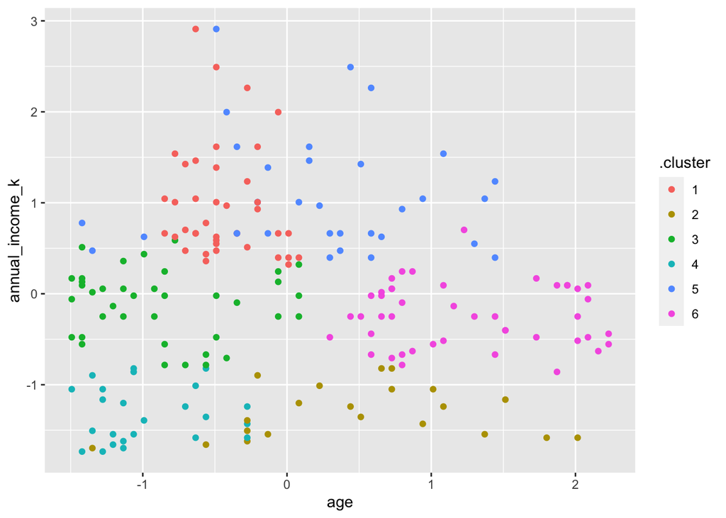

```r
unnested_k_clusters %>%
  unnest(cals = c(augmented)) %>%
  filter(k == 6) %>%
  ggplot() +
  aes(x = age, y = annual_income_k, colour = .cluster) +
  geom_point(aes(colour = .cluster))
```

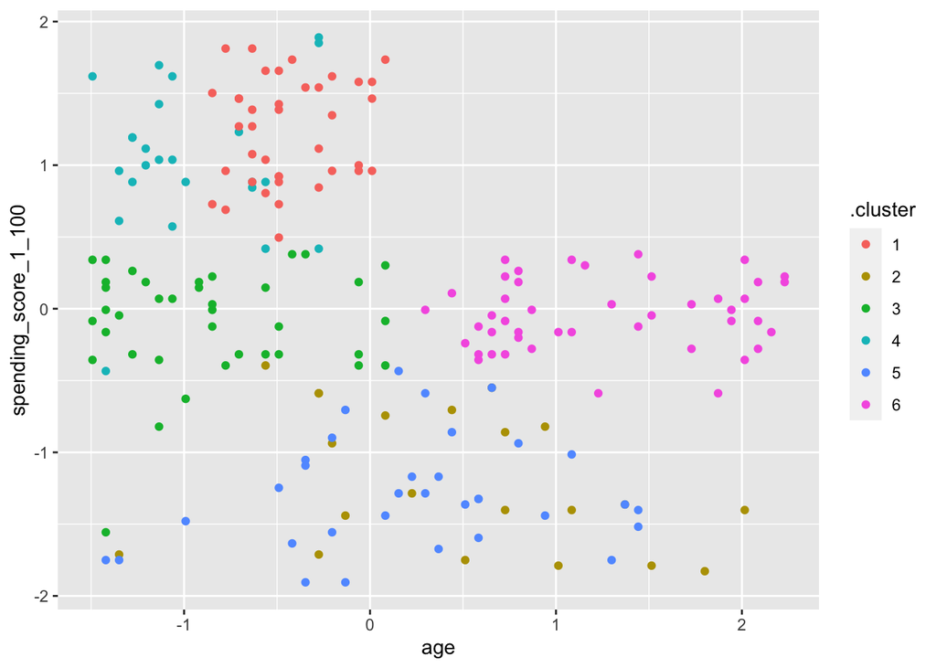

```r
unnested_k_clusters %>%
  unnest(cals = c(augmented)) %>%
  filter(k == 6) %>%
  ggplot() +
  aes(x = age, y = spending_score_1_100, colour = .cluster) +
  geom_point(aes(colour = .cluster))
```

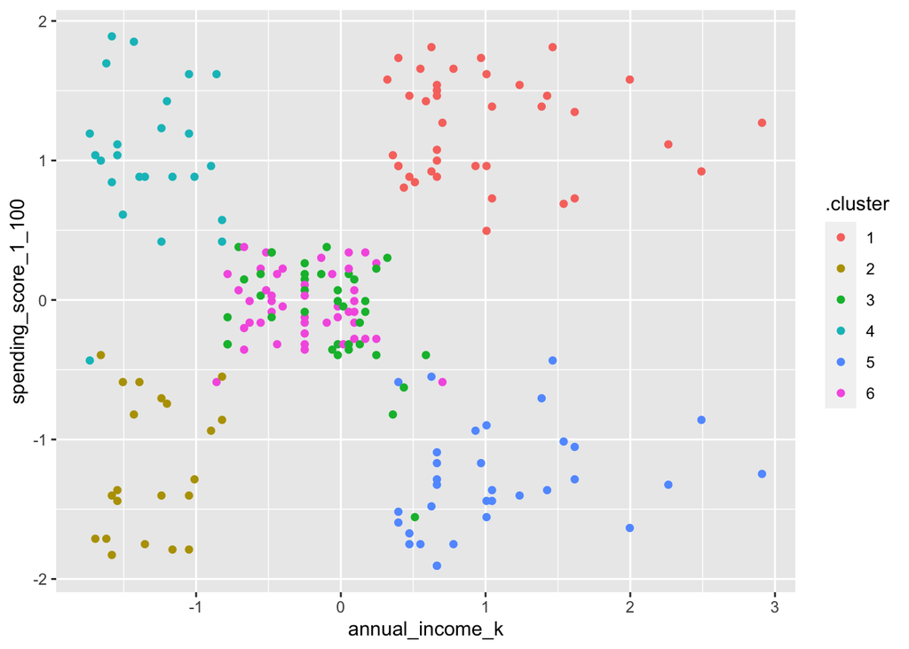

```r
unnested_k_clusters %>%
  unnest(cals = c(augmented)) %>%
  filter(k == 6) %>%
  ggplot() +
  aes(x = annual_income_k, y = spending_score_1_100, colour = .cluster) +
  geom_point(aes(colour = .cluster))
```

- Do you think the clustering seems a good fit for this data?

It seems ok. I would probably remove age from the clustering analysis and run the k-means clustering again.

- Comment on the attributes on one or two of the clusters (maybe even give them a label if you like - like in section 4.1 of the ‘Segmentation & clustering intro’ lesson).

I cannot find section 4.1 of the intro lesson? Maybe it has been relabeled?